# Crime Data Project

Nasim Lashaninejad, Rashmi Sarode, Anna Soto

Monday, August 3, 2015

[output not shown]

# Abstract

- DATA SOURCE
  - Collected from 1990 US Census, 1995 US FBI Uniform Crime Report, 1990 US Law Enforcement Management and Administrative Statistics Survey, available from ICPSR at U of Michigan.
  - Posted to UCI archive by creator Michael Redmond
  - http://archive.ics.uci.edu/ml/datasets/Communities+and+Crime+Unnormalized
- DATA DESCRIPTION: Violent crimes per 100k population for US counties (dependent variable) and several socio-economic statistics of those counties (predictors)
- AIMS - Use data to analyze correlation between violent crimes (dependent variable) and race, income, unemployment rate and police presence (independent variables) in several. Ultimately use the data to devise a predictive formula for violent crime rates.
- STATISTICAL ANALYSIS - performed using Rstudio

# Variable Descriptions

[output not shown]

# Data Summary

We replaced State and City with Region for location of crimes

|  | region | pctblack | pctWhite | pctAsian | pctHisp | medInc | pctUnemp | perPolice | perCrimes |
| --- | --- | --- | --- | --- | --- | --- | --- | --- | --- |
|  | Midwest : 28 | Min. : 0.1 | Min. : 7.2 | Min. : 0.2 | Min. : 0.4 | Min. :15312 | Min. : 2.11 | Min. : 29 | Min. : 52 |
|  | Northeast: 85 | 1st Qu.: 3.6 | 1st Qu.:61.6 | 1st Qu.: 1.0 | 1st Qu.: 2.3 | 1st Qu.:23595 | 1st Qu.: 5.21 | 1st Qu.: 148 | 1st Qu.: 496 |
|  | South :111 | Median :11.4 | Median :75.3 | Median : 1.8 | Median : 5.9 | Median :27700 | Median : 6.54 | Median : 194 | Median : 910 |
|  | West : 78 | Mean :18.0 | Mean :72.4 | Mean : 3.8 | Mean :12.8 | Mean :30493 | Mean : 6.97 | Mean : 250 | Mean :1104 |
|  | NA | 3rd Qu.:29.0 | 3rd Qu.:87.0 | 3rd Qu.: 4.0 | 3rd Qu.:16.3 | 3rd Qu.:35602 | 3rd Qu.: 8.52 | 3rd Qu.: 262 | 3rd Qu.:1558 |
|  | NA | Max. :90.0 | Max. :98.2 | Max. :57.5 | Max. :93.9 | Max. :81957 | Max. :16.60 | Max. :3437 | Max. :4027 |

# Psych Plot - Pearson Correlation Coefficients

- Positive correlation (0.665) between perCrimes and pctblack
- Positive correlation (0.537) between perCrimes and pctUnemp
- Negative correlation (-0.687) between perCrimes and pctWhite
- Negative correlation (-.491) between perCrimes and medInc

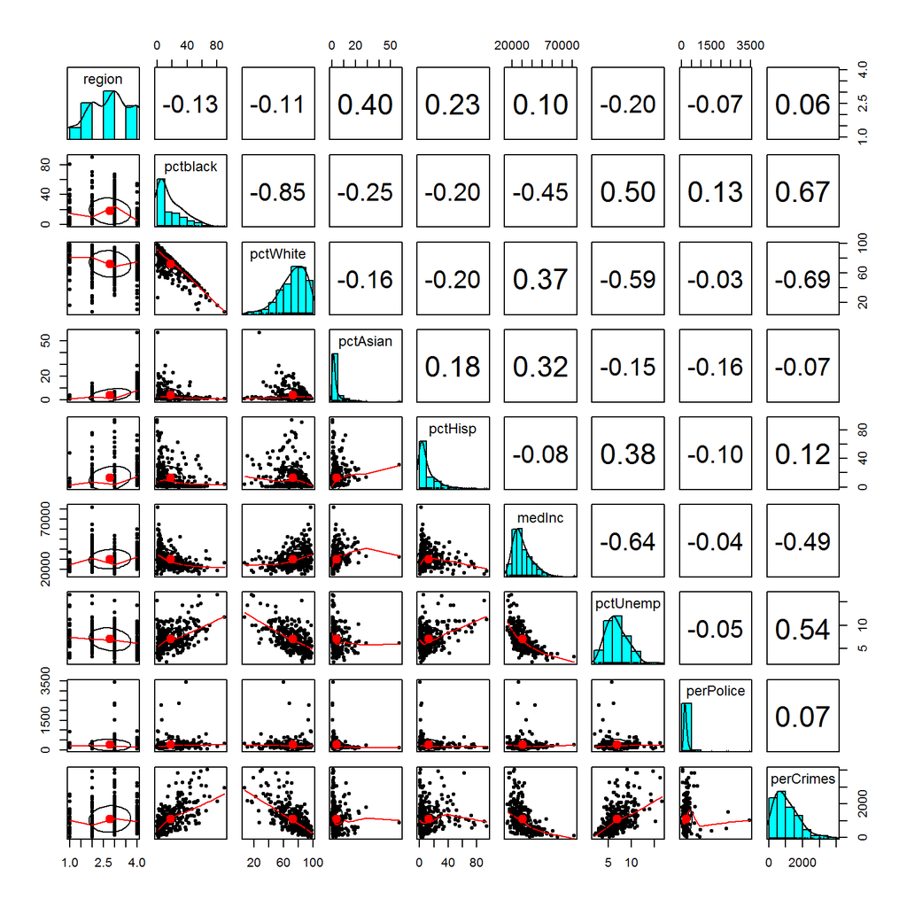

# Boxplot

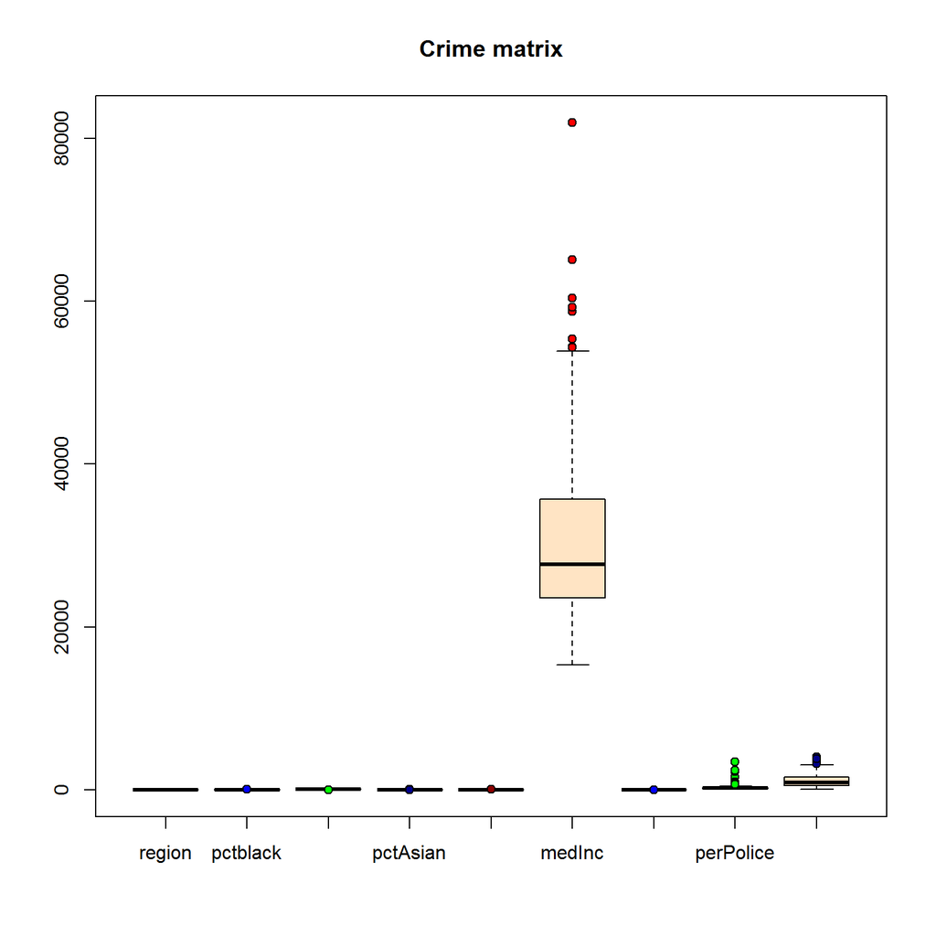

# Fit Plot

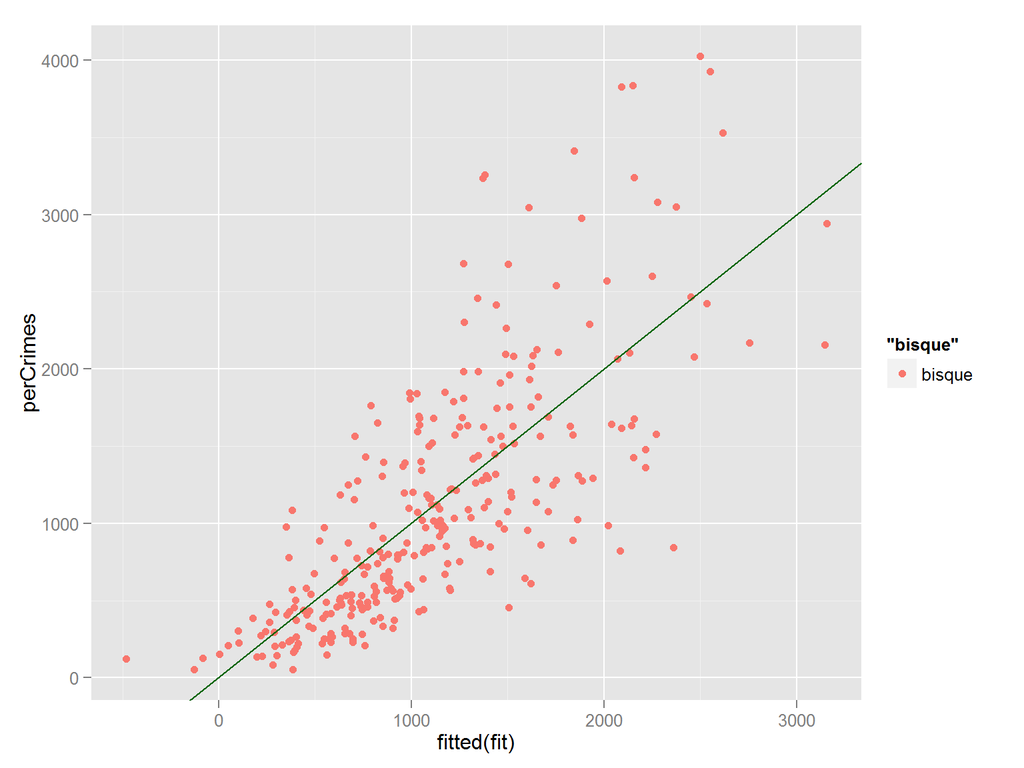

# Fit Summary

Adjusted R-squared: 0.553

```
##
## Call:
## lm(formula = perCrimes ~ region + pctWhite + pctblack + pctAsian +
##     pctHisp + medInc + pctUnemp + perPolice, data = Crime)
##
## Residuals:
##     Min      1Q  Median      3Q     Max
## -1516.1  -315.0   -91.7   211.0  1875.7
##
## Coefficients:
##                  Estimate Std. Error t value Pr(>|t|)
## (Intercept)      1.49e+02   1.03e+03    0.15   0.8847
## regionNortheast -1.72e+01   1.23e+02   -0.14   0.8888
## regionSouth      6.07e+00   1.22e+02    0.05   0.9603
## regionWest       2.96e+02   1.40e+02    2.11   0.0356
## pctWhite         5.46e+00   9.85e+00    0.55   0.5797
## pctblack         3.37e+01   1.04e+01    3.23   0.0014
## pctAsian         1.35e+01   1.19e+01    1.14   0.2556
## pctHisp          9.06e+00   4.11e+00    2.21   0.0282
## medInc          -1.62e-02   5.03e-03   -3.22   0.0014
## pctUnemp         2.62e+01   2.38e+01    1.10   0.2731
## perPolice        9.76e-02   1.09e-01    0.90   0.3699
##
## Residual standard error: 529 on 291 degrees of freedom
## Multiple R-squared:  0.568,  Adjusted R-squared:  0.553
## F-statistic: 38.2 on 10 and 291 DF,  p-value: <2e-16
```

# Checking Non-Constant Variance

For the following fitted linear model, the vertical width of the scatterplot increases across the fitted values indicating that the variance in the error terms is not constant.

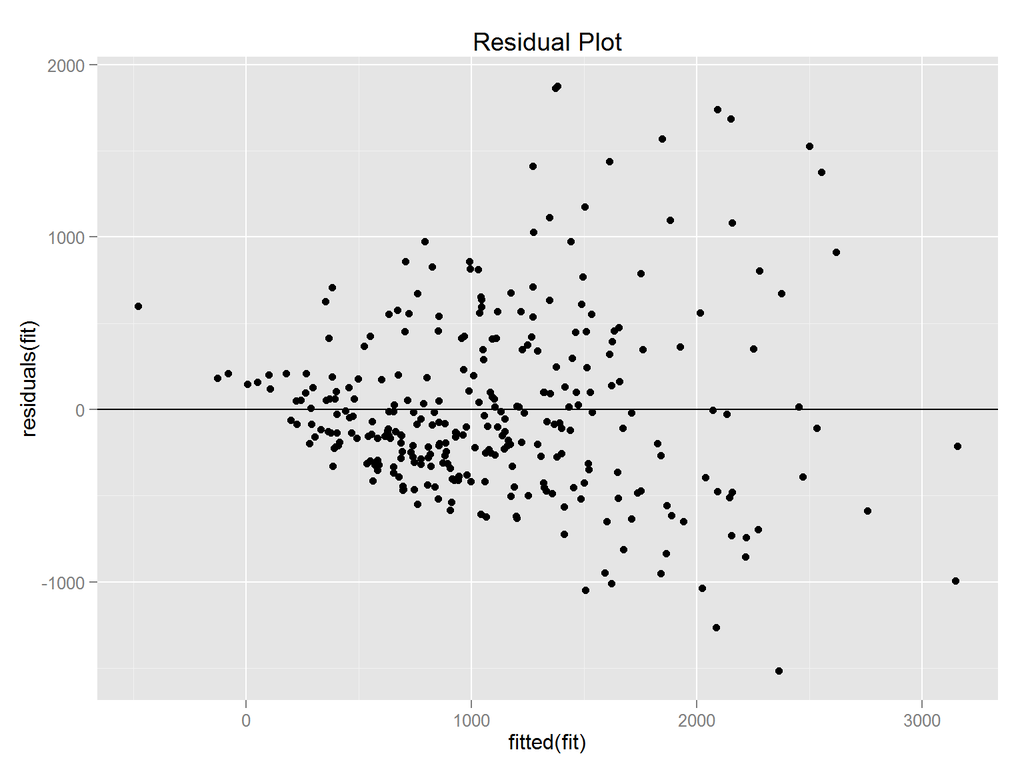

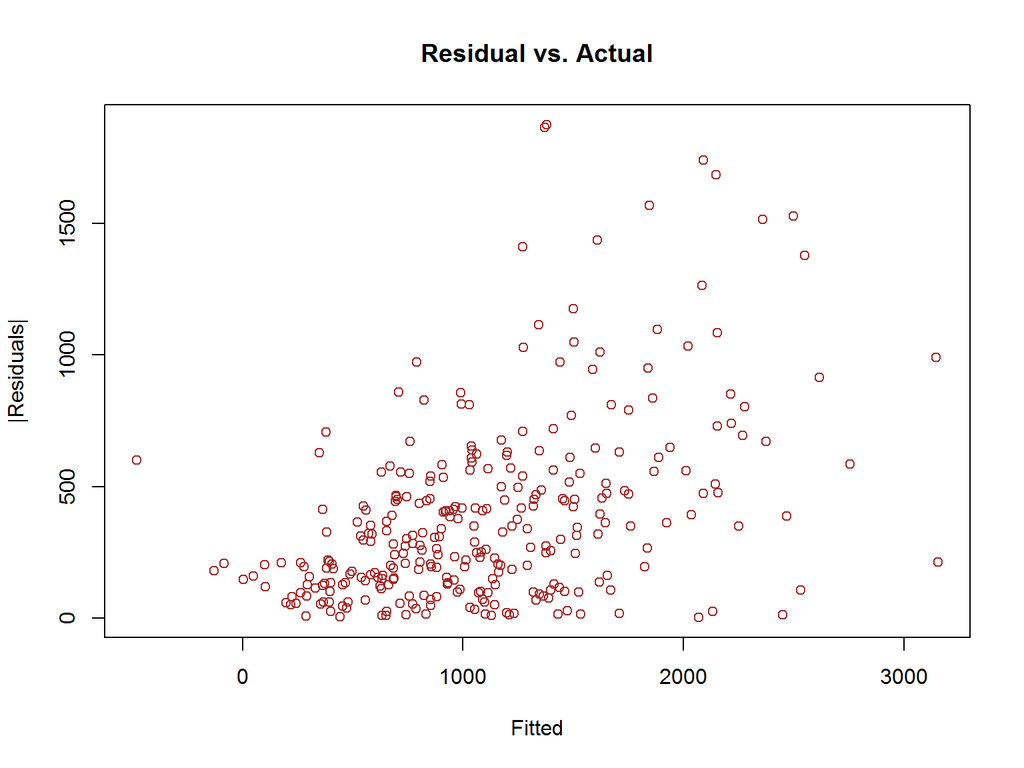

# Checking Non-Constant Variance using Transformation of Data

### The goodness of fit measure, r-squared, increases to .631 when taking the log of the data

When transforming the data by fitting the linear models with the log values of the predictors, the residual plot shows that the points are randomly scattered around zero, indicating that error terms have a mean near zero. The vertical width of the scatter doesn’t appear to increase or decrease across the fitted values, so we assume that the variance in the error terms is constant.

```r
fit <-  lm(log(perCrimes) ~ region + pctWhite + pctblack + pctAsian + pctHisp + medInc + pctUnemp + perPolice, data=Crime)
```

R-Squared Value:

```
## [1] 0.631
```

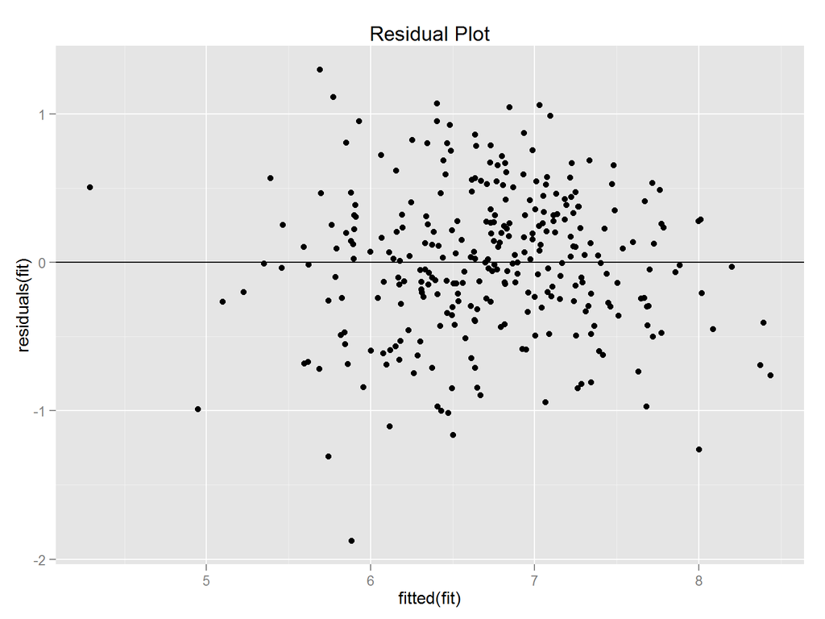

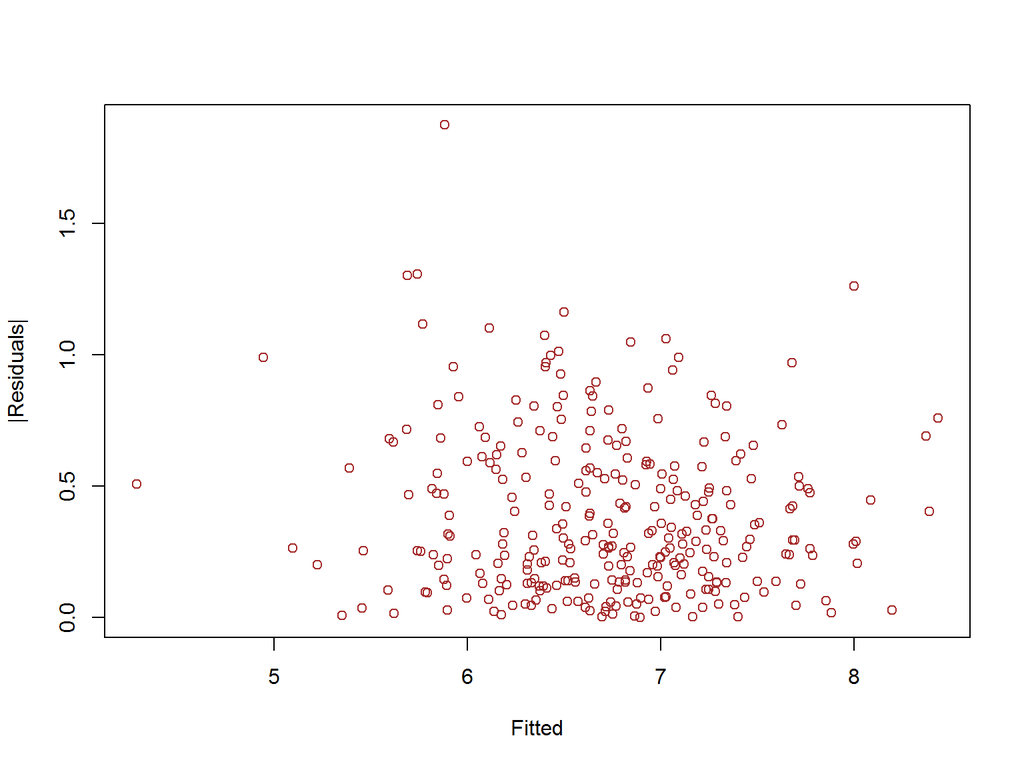

# Checking for non-normal error distribution

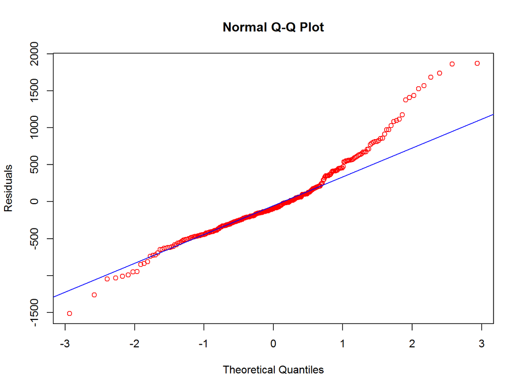

# Remove Nominal Attribute To Created Scaled Stripchart

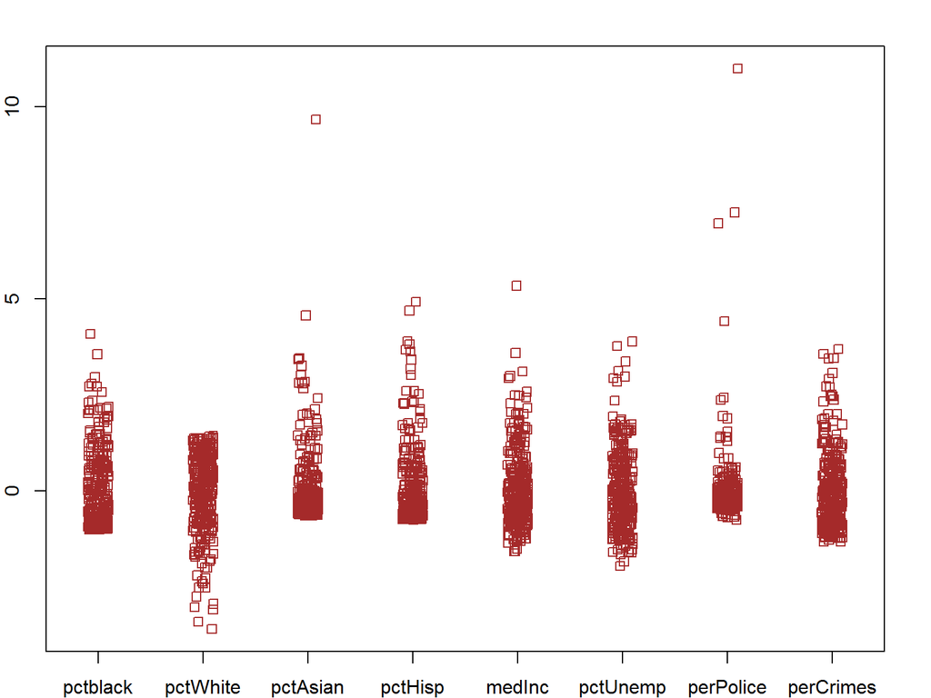

# Hypothesis Testing

### Big model (with all predictors):

```
##
## Call:
## lm(formula = perCrimes ~ region + pctWhite + pctblack + pctAsian +
##     pctHisp + medInc + pctUnemp + perPolice, data = Crime)
##
## Residuals:
##     Min      1Q  Median      3Q     Max
## -1516.1  -315.0   -91.7   211.0  1875.7
##
## Coefficients:
##                  Estimate Std. Error t value Pr(>|t|)
## (Intercept)      1.49e+02   1.03e+03    0.15   0.8847
## regionNortheast -1.72e+01   1.23e+02   -0.14   0.8888
## regionSouth      6.07e+00   1.22e+02    0.05   0.9603
## regionWest       2.96e+02   1.40e+02    2.11   0.0356
## pctWhite         5.46e+00   9.85e+00    0.55   0.5797
## pctblack         3.37e+01   1.04e+01    3.23   0.0014
## pctAsian         1.35e+01   1.19e+01    1.14   0.2556
## pctHisp          9.06e+00   4.11e+00    2.21   0.0282
## medInc          -1.62e-02   5.03e-03   -3.22   0.0014
## pctUnemp         2.62e+01   2.38e+01    1.10   0.2731
## perPolice        9.76e-02   1.09e-01    0.90   0.3699
##
## Residual standard error: 529 on 291 degrees of freedom
## Multiple R-squared:  0.568,  Adjusted R-squared:  0.553
## F-statistic: 38.2 on 10 and 291 DF,  p-value: <2e-16
```

# Hypothesis Testing

### Small model (after removing following predictors from the full linear model):

#### region, pctBlack, pctHisp, medInc

```
##
## Call:
## lm(formula = perCrimes ~ pctWhite + pctAsian + pctUnemp + perPolice,
##     data = Crime)
##
## Residuals:
##    Min     1Q Median     3Q    Max
##  -1290   -353   -123    203   2236
##
## Coefficients:
##             Estimate Std. Error t value Pr(>|t|)
## (Intercept) 2754.055    277.614    9.92   <2e-16
## pctWhite     -26.926      2.321  -11.60   <2e-16
## pctAsian     -19.103      6.251   -3.06   0.0024
## pctUnemp      49.335     16.983    2.90   0.0039
## perPolice      0.115      0.113    1.02   0.3103
##
## Residual standard error: 554 on 297 degrees of freedom
## Multiple R-squared:  0.518,  Adjusted R-squared:  0.511
## F-statistic: 79.7 on 4 and 297 DF,  p-value: <2e-16
```

#### Test Result: We reject the Null Hypothesis that there is no linear correlation and say that there is significant positive linear correlation between the total number of violent crimes per 100K population and the predictors in the model

# ANOVA Test

### Analysis of Variance Table

- Model 1: perCrimes ~ pctWhite + pctAsian + pctUnemp + perPolice
- Model 2: perCrimes ~ region + pctWhite + pctblack + pctAsian + pctHisp + medInc + pctUnemp + perPolice

| Res.Df | RSS | Df | Sum of Sq | F | Pr(>F) |
| --- | --- | --- | --- | --- | --- |
| 297 | 91073631 | NA | NA | NA | NA |
| 291 | 81586262 | 6 | 9487369 | 5.64 | 0 |

#### Conclusion: Reject the null hypothesis and keep excluded predictors in the model

# Automated Model Selection

This model removes the attributes with the lowest AIC: pctWhite, pctAsian, pctUnemp , perPolice.

```
## Start:  AIC=3799
## perCrimes ~ region + pctblack + pctWhite + pctAsian + pctHisp +
##     medInc + pctUnemp + perPolice
##
##             Df Sum of Sq      RSS  AIC
## - pctWhite   1     86195 81672457 3797
## - perPolice  1    226135 81812397 3798
## - pctUnemp   1    338042 81924304 3798
## - pctAsian   1    363823 81950085 3798
## <none>                   81586262 3799
## - pctHisp    1   1364518 82950780 3802
## - region     3   2922067 84508329 3804
## - medInc     1   2907974 84494237 3808
## - pctblack   1   2923497 84509759 3808
##
## Step:  AIC=3797
## perCrimes ~ region + pctblack + pctAsian + pctHisp + medInc +
##     pctUnemp + perPolice
##
##             Df Sum of Sq      RSS  AIC
## - perPolice  1    235277 8.19e+07 3796
## - pctUnemp   1    310240 8.20e+07 3797
## - pctAsian   1    397363 8.21e+07 3797
## <none>                   8.17e+07 3797
## - region     3   2953625 8.46e+07 3802
## - pctHisp    1   2325080 8.40e+07 3804
## - medInc     1   2875941 8.45e+07 3806
## - pctblack   1  34130701 1.16e+08 3901
##
## Step:  AIC=3796
## perCrimes ~ region + pctblack + pctAsian + pctHisp + medInc +
##     pctUnemp
##
##            Df Sum of Sq      RSS  AIC
## - pctUnemp  1    258590 8.22e+07 3795
## - pctAsian  1    356061 8.23e+07 3796
## <none>                  8.19e+07 3796
## - region    3   2838326 8.47e+07 3801
## - pctHisp   1   2378615 8.43e+07 3803
## - medInc    1   2911814 8.48e+07 3805
## - pctblack  1  35246744 1.17e+08 3902
##
## Step:  AIC=3795
## perCrimes ~ region + pctblack + pctAsian + pctHisp + medInc
##
##            Df Sum of Sq      RSS  AIC
## - pctAsian  1    379248 8.25e+07 3795
## <none>                  8.22e+07 3795
## - region    3   2698299 8.49e+07 3799
## - pctHisp   1   5273781 8.74e+07 3812
## - medInc    1   6418048 8.86e+07 3816
## - pctblack  1  56933473 1.39e+08 3952
##
## Step:  AIC=3795
## perCrimes ~ region + pctblack + pctHisp + medInc
##
##            Df Sum of Sq      RSS  AIC
## <none>                  8.25e+07 3795
## - region    3   4884327 8.74e+07 3806
## - pctHisp   1   5581956 8.81e+07 3812
## - medInc    1   6042641 8.86e+07 3814
## - pctblack  1  57423282 1.40e+08 3952
```

# Leveraged Points

Finding the influential points can have an effect on selected model. We sorted the data based on their influence and decided to remove the top two with the highest influence.

[output not shown]

[output cut: 13 more lines]

[output not shown]

# Remove Points With Higher Influence:

Deleting the following points: 1026.28 and 893.29. The effect of leveraged points is low in our sample.

[output not shown]

# Leveraged Model vs.Automated Step Model vs. Non-Leveraged

Leveraged Model (Original):

```
##     (Intercept) regionNortheast     regionSouth      regionWest
##        149.4027        -17.2302          6.0743        296.1546
##        pctblack        pctWhite        pctAsian         pctHisp
##         33.7139          5.4617         13.5334          9.0632
##          medInc        pctUnemp       perPolice
##         -0.0162         26.1505          0.0976
```

Automated Step Model:

```
##     (Intercept) regionNortheast     regionSouth      regionWest
##        938.5859         -9.4154        -23.5701        303.4528
##        pctblack         pctHisp          medInc
##         29.8423          9.0014         -0.0181
```

Non-Leveraged Model (two points removed):

```
##     (Intercept) regionNortheast     regionSouth      regionWest
##        938.5859         -9.4154        -23.5701        303.4528
##        pctblack         pctHisp          medInc
##         29.8423          9.0014         -0.0181
```

# Cross-Validation

Use a different seed for choosing different random folds (3 folds default). We “shake” the data for new validations and compare several cross-validations graphs:

For Original:

```
## Analysis of Variance Table
##
## Response: perCrimes
##            Df   Sum Sq  Mean Sq F value  Pr(>F)
## region      3  9089568  3029856   10.81 9.4e-07
## pctblack    1 81411914 81411914  290.38 < 2e-16
## pctWhite    1  5235303  5235303   18.67 2.1e-05
## pctAsian    1  2178222  2178222    7.77  0.0057
## pctHisp     1  2290055  2290055    8.17  0.0046
## medInc      1  6483962  6483962   23.13 2.4e-06
## pctUnemp    1   286773   286773    1.02  0.3127
## perPolice   1   226135   226135    0.81  0.3699
## Residuals 291 81586262   280365
```

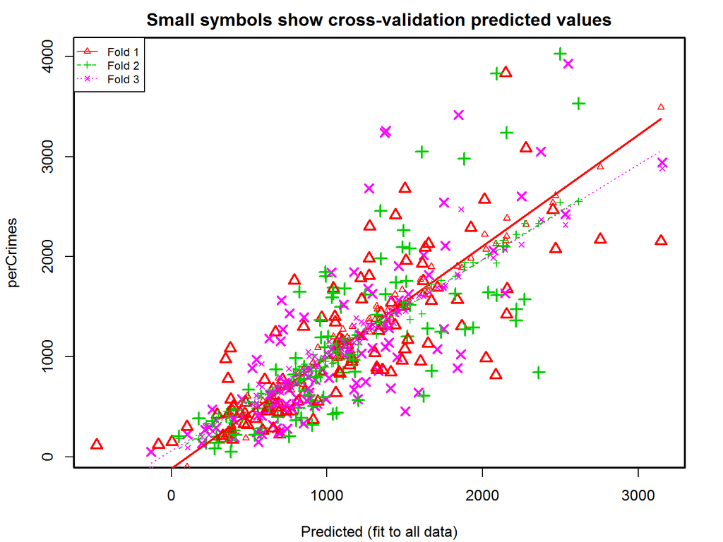

[output not shown]

[output cut: 99 more lines]

```
## Predicted   1145.6 1014 1173 2376 1397.4 2250 1398 1173 1029 1463 1760
## cvpred      1052.9 1155 1315 2372 1369.5 2122 1435 1145 1012 1445 1715
## perCrimes   1093.2  793  673 3048 1290.4 2602 1142 1849 1841 1564 2110
## CV residual   40.3 -362 -643  676  -79.1  479 -293  705  829  120  395
##              264  279  280  283  287  288  293  294  296 299
## Predicted   2532 1656 2551 1271 1188 1846 1380 1371 1107 548
## cvpred      2319 1642 2398 1305 1391 1801 1330 1401 1164 613
## perCrimes   2423 1819 3928 2682  740 3415 3256 3235 1523 974
## CV residual  105  177 1530 1377 -652 1614 1926 1834  359 361
##
## Sum of squares = 3.3e+07    Mean square = 327067    n = 101
##
## Overall (Sum over all 101 folds)
##     ms
## 303236
```

# Cross-Validation

For g_step:

```
## Analysis of Variance Table
##
## Response: perCrimes
##            Df   Sum Sq  Mean Sq F value  Pr(>F)
## region      3  9089568  3029856    10.8 9.1e-07
## pctblack    1 81411914 81411914   290.9 < 2e-16
## pctHisp     1  9698498  9698498    34.7 1.1e-08
## medInc      1  6042641  6042641    21.6 5.1e-06
## Residuals 295 82545572   279815
```

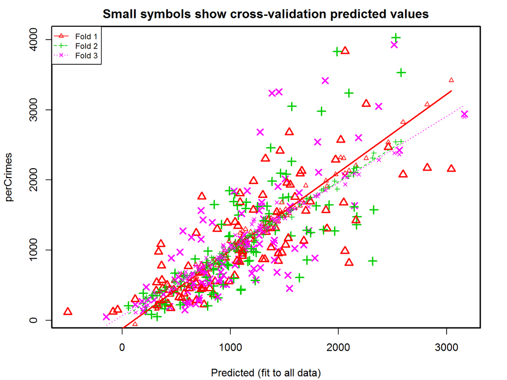

[output not shown]

[output cut: 99 more lines]

```
## Predicted   2372 1334.3 2186 1407 1157 1036 1267 1816 2562.6 1636 2516
## cvpred      2285 1319.0 2078 1449 1139 1029 1283 1800 2366.1 1687 2384
## perCrimes   3048 1290.4 2602 1142 1849 1841 1564 2110 2423.5 1819 3928
## CV residual  763  -28.6  523 -307  710  813  282  310   57.4  132 1544
##              283  287  288  293  294  296 299
## Predicted   1275 1218 1877 1449 1385 1104 533
## cvpred      1307 1442 1855 1459 1446 1162 679
## perCrimes   2682  740 3415 3256 3235 1523 974
## CV residual 1376 -702 1560 1797 1790  361 296
##
## Sum of squares = 31563607    Mean square = 312511    n = 101
##
## Overall (Sum over all 101 folds)
##     ms
## 298177
```

# Confidence intervals

|  | 2.5 % | 97.5 % |
| --- | --- | --- |
| (Intercept) | -1876.312 | 2175.117 |
| regionNortheast | -259.575 | 225.114 |
| regionSouth | -233.844 | 245.993 |
| regionWest | 20.091 | 572.218 |
| pctblack | 13.166 | 54.262 |
| pctWhite | -13.925 | 24.848 |
| pctAsian | -9.849 | 36.916 |
| pctHisp | 0.978 | 17.149 |
| medInc | -0.026 | -0.006 |
| pctUnemp | -20.722 | 73.023 |
| perPolice | -0.116 | 0.312 |

# Confidence interval with Bonferroni

|  | 0.156 % | 99.844 % |
| --- | --- | --- |
| (Intercept) | -2917.827 | 3216.633 |
| regionNortheast | -384.175 | 349.715 |
| regionSouth | -357.198 | 369.346 |
| regionWest | -121.846 | 714.156 |
| pctblack | 2.601 | 64.827 |
| pctWhite | -23.893 | 34.816 |
| pctAsian | -21.870 | 48.937 |
| pctHisp | -3.180 | 21.306 |
| medInc | -0.031 | -0.001 |
| pctUnemp | -44.821 | 97.122 |
| perPolice | -0.226 | 0.422 |

# Ellipse - Joint Confidence Region

We use 2 attributes to create ellips: medInc and pct Unemp

[figure not shown]

```
                                      Thank you!
                                    ANY Questions?
```